# Integrate ComplexHeatmap with cowplot package

Zuguang Gu

2020-07-14

[The **cowplot** package](https://cran.r-project.org/web/packages/cowplot/index.html) is used to combine multiple plots into a single figure. In most cases, **ComplexHeatmap** works perfectly with **cowplot**, but there are some cases that need special attention.

Also there are some other packages that combine multiple plots, such as [**multipanelfigure**](https://cran.r-project.org/web/packages/multipanelfigure/index.html), but I think the mechanism behind is the same.

Following functionalities in **ComplexHeatmap** cause problems with using **cowplot**.

1. [`anno_zoom()`/`anno_link()`](https://jokergoo.github.io/ComplexHeatmap-reference/book/heatmap-annotations.html#zoom-annotation). The adjusted positions by these two functions rely on the size of the graphics device.
2. [`anno_mark()`](https://jokergoo.github.io/ComplexHeatmap-reference/book/heatmap-annotations.html#mark-annotation). The same reason as `anno_zoom()`. The adjusted positions also rely on the device size.
3. [When there are too many legends, the legends will be wrapped into multiple columns](https://jokergoo.github.io/ComplexHeatmap-reference/book/legends.html#heatmap-and-annotation-legends). The calculation of the legend positions rely on the device size.

In following I demonstrate a case with using the `anno_zoom()`. Here the example is from [the **simplifyEnrichment** package](https://github.com/jokergoo/simplifyEnrichment) and the plot shows a GO similarity heatmap with word cloud annotation showing the major biological functions in each group.

You don’t need to really understand the following code. The `ht_clusters()` function basically draws a heatmap with `Heatmap()` and add the word cloud annotation by `anno_zoom()`.

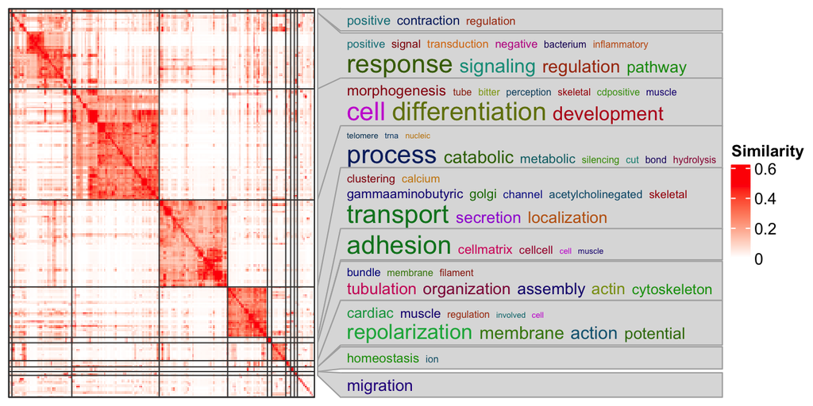

```r
library(simplifyEnrichment)
set.seed(1234)
go_id = random_GO(500)
mat = GO_similarity(go_id)
cl = binary_cut(mat)
ht_clusters(mat, cl)
```

Next we put this heatmap as a sub-figure with **cowplot**. To integrate with **cowplot**, the heatmap should be captured by `grid::grid.grabExpr()` as a complex `grob` object. Note here you need to use `draw()` function to draw the heatmap explicitly.

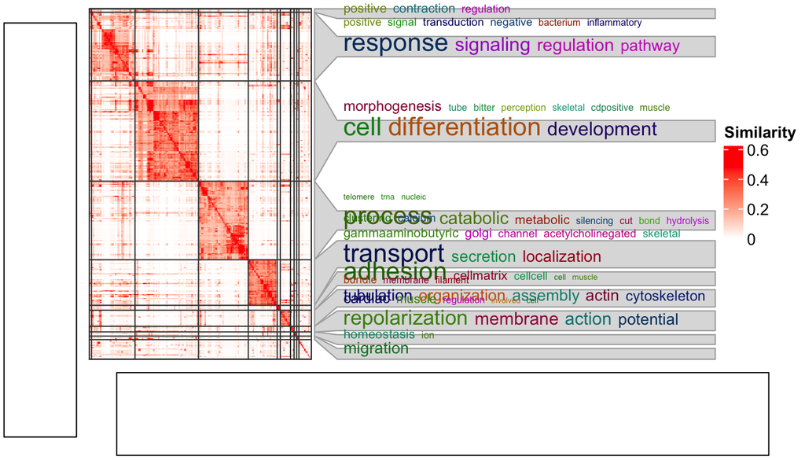

```r
library(cowplot)
library(grid)
p1 = rectGrob(width = 0.9, height = 0.9)
p2 = grid.grabExpr(ht_clusters(mat, cl))
p3 = rectGrob(width = 0.9, height = 0.9)

plot_grid(p1,
    plot_grid(p2, p3, nrow = 2, rel_heights = c(4, 1)),
    nrow = 1, rel_widths = c(1, 9)
)
```

Woooo! The word cloud annotation is badly aligned.

There are some details that should be noted for `grid.grabExpr()` function. It actually opens an invisible graphics device (by `pdf(NULL)`) with a default size 7x7 inches. Thus, for this line:

```r
p2 = grid.grabExpr(ht_clusters(mat, cl))
```

The word cloud annotation in `p2` is actually calculated in a region of 7x7 inches, and when it is written back to the figure by `plot_grid()`, the space for `p2` changes, that is why the word cloud annotation is wrongly aligned.

On the other hand, if “a simple heatmap” is captured by `grid.grabExpr()`, *e.g.*:

```r
p2 = grid.grabExpr(draw(Heatmap(mat)))
```

when `p2` is put back, everything will work fine because now all the heatmap elements are not dependent on the device size and the positions will be automatically adjusted to the new space.

This effect can also be observed by plotting the heatmap in the interactive graphics device and resizing the window by dragging it.

The solution is rather simple. Since the reason for this inconsistency is the different space between where it is captured and where it is drawn, we only need to capture the heatmap under the device with the same size as where it is going to be put.

As in the layout which we set in the `plot_grid()` function, the heatmap occupies 9/10 width and 4/5 height of the figure. So, the width and height of the space for the heatmap is calculated as follows and assigned to the `width` and `height` arguments in `grid.grabExpr()`.

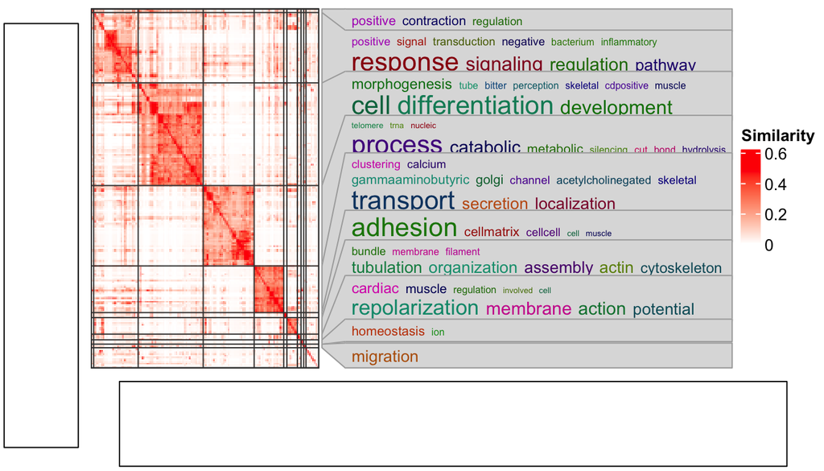

```r
w = convertWidth(unit(1, "npc")*(9/10), "inch", valueOnly = TRUE)
h = convertHeight(unit(1, "npc")*(4/5), "inch", valueOnly = TRUE)
p2 = grid.grabExpr(ht_clusters(mat, cl), width = w, height = h)

plot_grid(p1,
    plot_grid(p2, p3, nrow = 2, rel_heights = c(4, 1)),
    nrow = 1, rel_widths = c(1, 9)
)
```

Now everthing is back to normal!